# ChIPseq in Bioconductor exercises

Tom Carroll

## ChIPseq data processing

In these exercises we will review some of the functionality of ChIPQC, reading in peaks and annotating peaks to genes.

We will be using data directly downloaded from the Encode consortium.

Precomputed ChIPQC results as a list for 2 Encode CTCF samples and their input can be found in the Data directory.

**Data/CTCFQC.RData**

We will also perform some of our own QC on some human data of Pancreas CTCF data. We should download thew BAM file [here](https://www.encodeproject.org/files/ENCFF789ZHS/@@download/ENCFF789ZHS.bam)

We can also retrieve the relevant peak calls from [here](https://www.encodeproject.org/files/ENCFF627LTJ/@@download/ENCFF627LTJ.bed.gz)

1. Load the CTCFQC.RData into R
2. Produce a cross coverage plot from these samples using ChIPQC. Add metadata for antibody

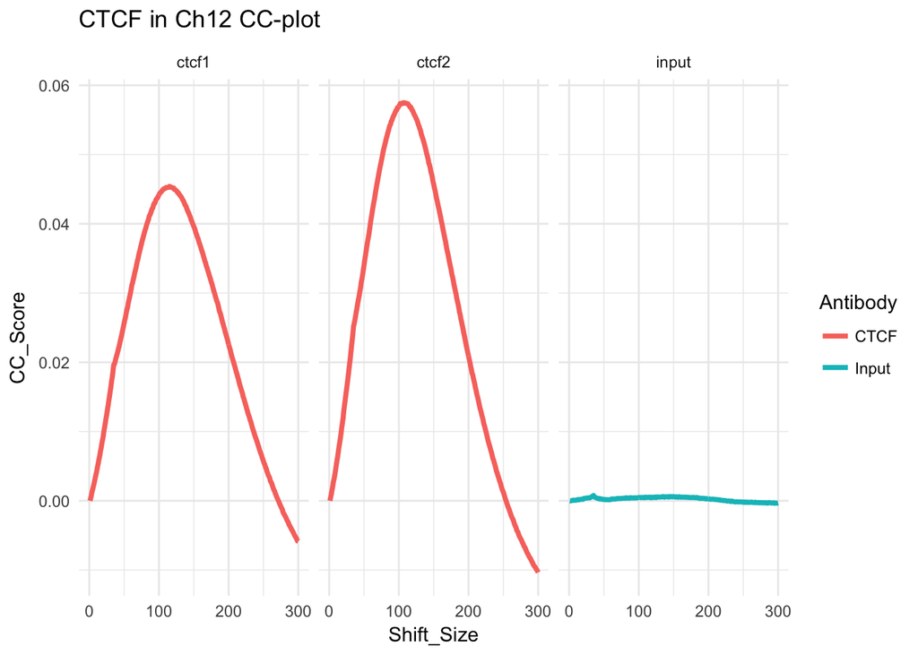

3. Create a barplot of the percentage of duplicates in samples.

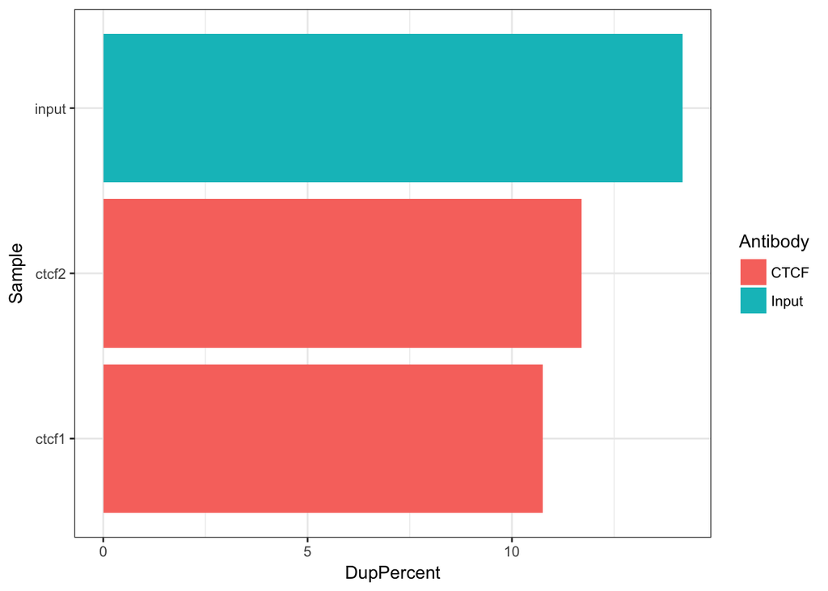

4. Plot the enrichment of reads over regions as seen below.

[output not shown]

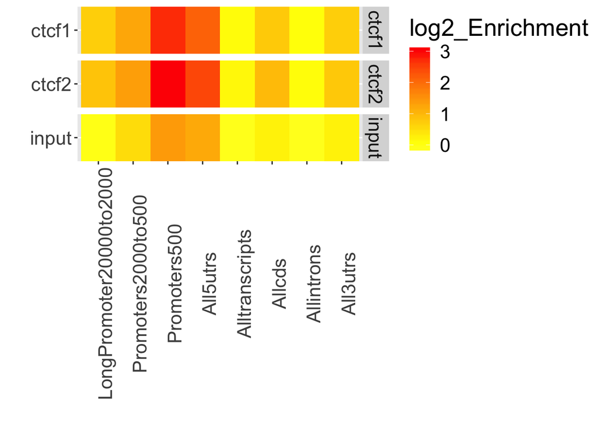

5. Plot the SSD of the CTCF samples as seen below.

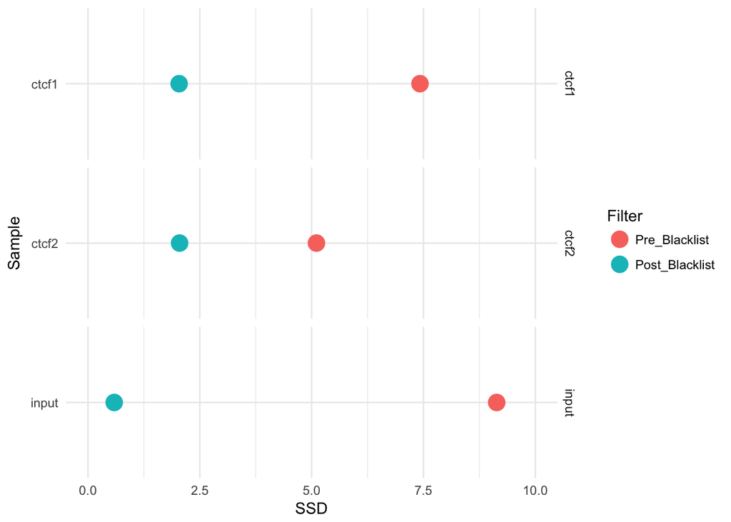

6. With the downloaded peak calls in ENCFF627LTJ.bed.gz, import into R, filter to chromosomes chr1 to chr21 and plot the number of peaks these chromosomes.

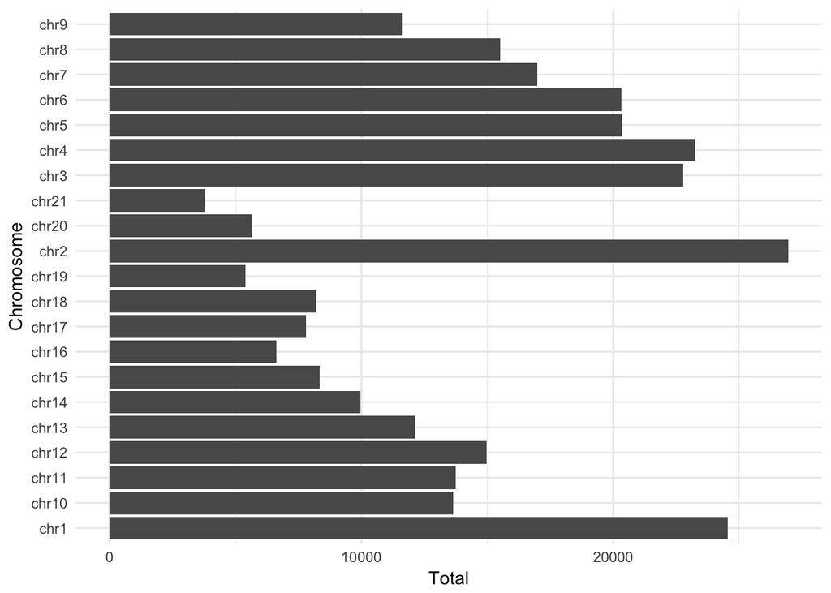

7. Annotate these peaks to genes using the ChIPseeker package.

[output not shown]

```
## >> assigning chromosome lengths           2018-05-11 11:40:45
## >> done...                    2018-05-11 11:40:45
```

8. Create a pie chart of annotation of peaks by ChIPseeker

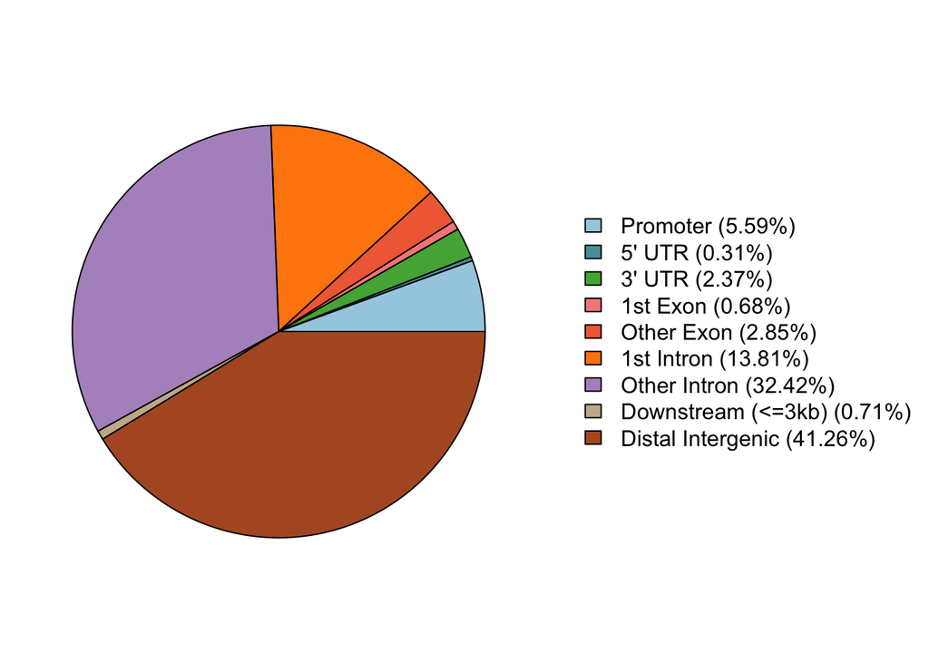

0. Export annotated peaks to a tab separated file.
1. Download the blacklist for [hg38](https://www.encodeproject.org/annotations/ENCSR636HFF/) and QC our newly downloaded BAM file in ChIPQC. To save time only run ChIPQC on chromosomes (chr10, chr11,chr12). Create cross-coverage plot using ChIPQC.

```
## [1] 1
```

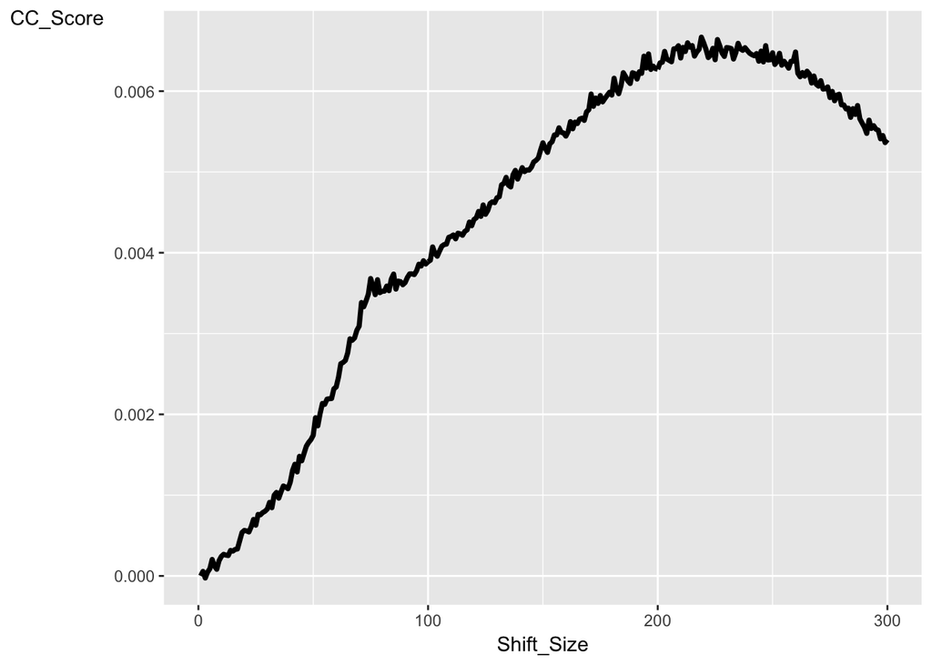